# Design Detectives: DataLab

Week 12 Lab Activity

Author

Gordon Wright

Published

22 January 2026

**NoteHow This Works**

This activity accompanies the **instructor slides**. Your instructor will guide you through each phase:

1. **Task overview** (instructor presents)
2. **Group discussion** (you work through questions below)
3. **Whole-class debrief** (we discuss answers together)

Form groups of **2-3 people** and work through each section when prompted.

**TipGlossary Links**

Key terms are linked to the glossary. If you’re unsure about terminology, click the links to review definitions.

## Task 1: Reflex Test

### What You Did

You caught a falling 30cm ruler five times. The distance you caught it at reflects your reaction time - shorter distance means faster reactions.

### Your Results

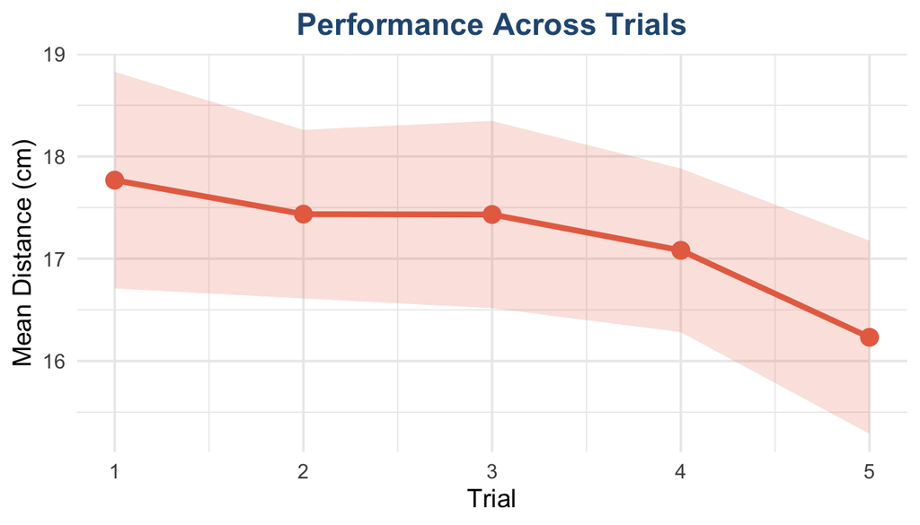

### Group Discussion Questions

**Q1.1** Look at the graph. What happens to performance from Trial 1 to Trial 5?

**Q1.2** Were the **same people** tested in all 5 trials, or **different people** in each trial?

**Q1.3** What design type is this? (See within-subjects design)

**Q1.4** What is the **Independent Variable (IV)**?

**Q1.5** What is the **Dependent Variable (DV)**?

**Q1.6** Write a **one-tailed hypothesis** for this experiment:

**TipExample Answer**

“Reaction time will decrease (improve) from Trial 1 to Trial 5” OR “Catch distance will decrease from Trial 1 to Trial 5”

This is a **practice effect** - performance improves with repetition.

## Task 2: Time Warp

### What You Did

You estimated 60 seconds without counting. We wanted to see if people systematically over- or underestimate time.

### Your Results

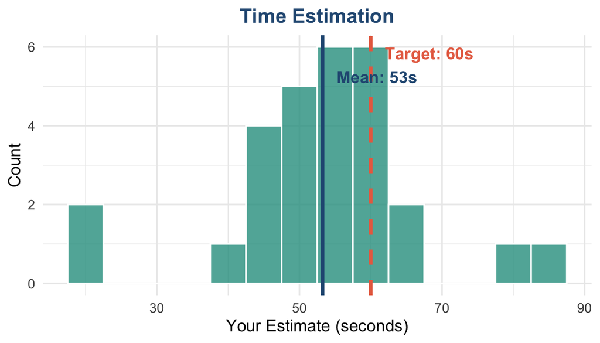

### Group Discussion Questions

**Q2.1** On average, did people over- or underestimate 60 seconds?

**Q2.2** What does it mean if someone underestimates 60 seconds?

**Q2.3** This experiment compares people’s estimates to a known target (60 seconds). The **null hypothesis** would be:

## Task 3: Memory

### The Secret Manipulation

Here’s what you didn’t know: **Lab A** and **Lab B** saw different words!

- **Lab A**: Abstract words (justice, freedom, wisdom…)
- **Lab B**: Concrete words (chair, river, mountain…)

### Your Results

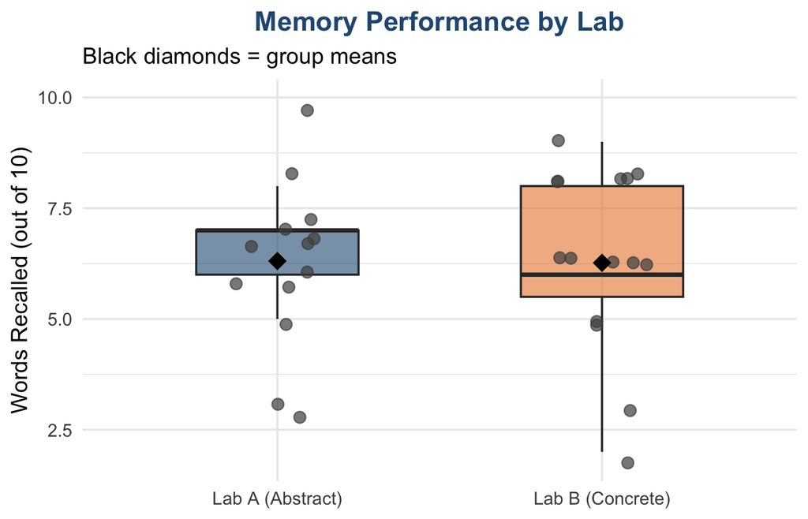

### Descriptive Statistics

Memory scores by lab group

| Lab | n | Mean | SD |
| --- | --- | --- | --- |
| Lab A (Abstract) | 13 | 6.31 | 1.89 |
| Lab B (Concrete) | 15 | 6.27 | 1.98 |

### Group Discussion Questions

**Q3.1** What is the **Independent Variable (IV)**?

**Q3.2** What is the **Dependent Variable (DV)**?

**Q3.3** Were the same people in both labs?

**Q3.4** What design type is this? (See between-subjects design)

**Q3.5** Write an **experimental hypothesis (H1)** - one-tailed:

**Q3.6** Write a **null hypothesis (H0)**:

**Q3.7** Why might concrete words be easier to remember?

**TipThe Answer: Dual Coding Theory**

Concrete words can be stored in TWO ways: as a verbal code (the word) AND as a visual image (you can picture “chair”). Abstract words only have the verbal code. Two codes = better memory.

## Task 4: Frontal Lob

### What You Did

You threw balls at a bucket:

- 10 throws with your **dominant hand**
- 5 throws with your **non-dominant hand**

### Your Results

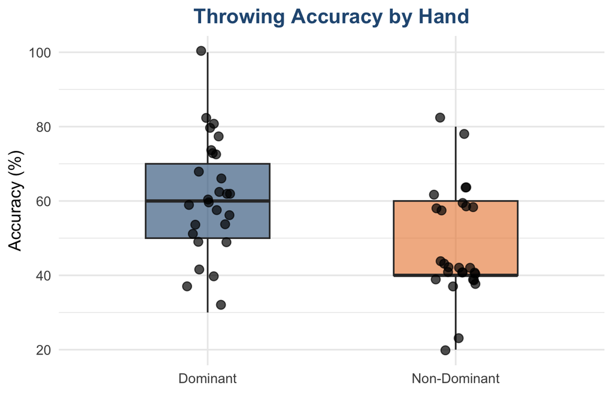

### Group Discussion Questions

**Q4.1** Were the same people tested with both hands?

**Q4.2** What design type is this? (See within-subjects design)

**Q4.3** What is the **IV**?

**Q4.4** What is the **DV**?

**Q4.5** Why is within-subjects design considered “more powerful”?

**Q4.6** Which statistical test would you use to compare dominant vs non-dominant hand?

## Task 5: Sleep & Memory

### The Question

Before the session, you told us how many hours you slept last night. We also measured how many words you recalled.

**Is there a relationship between sleep and memory?**

### Your Results

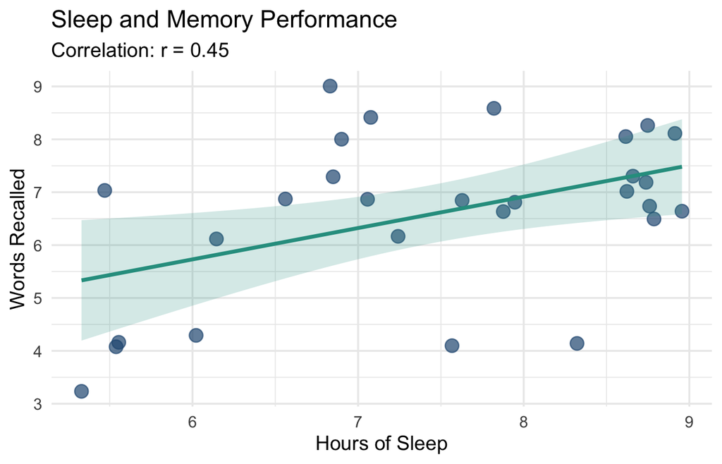

### Group Discussion Questions

**Q5.1** Is there an IV in this study?

**Q5.2** What design type is this? (See correlational design)

**Q5.3** What does a positive correlation mean here?

**Q5.4** Can we say that sleep **causes** better memory based on this data?

**Q5.5** Why can’t we make causal claims from correlational data?

**WarningThe Critical Point: Correlation ≠ Causation**

Even if we find a relationship between sleep and memory, we **cannot** say sleep *causes* better memory. Why?

- Maybe healthier people sleep more AND have better memory
- Maybe motivated students prepare better (sleep AND study)
- Maybe stress reduces both sleep AND memory

This is why **experiments** (with manipulation) are needed to establish causation.

## Task 6: Sixth Sense

### What You Did

6 trials: Someone either stared at you or didn’t. You guessed which.

**If just guessing randomly**: You’d expect to get 3 out of 6 correct (50%).

### Your Results

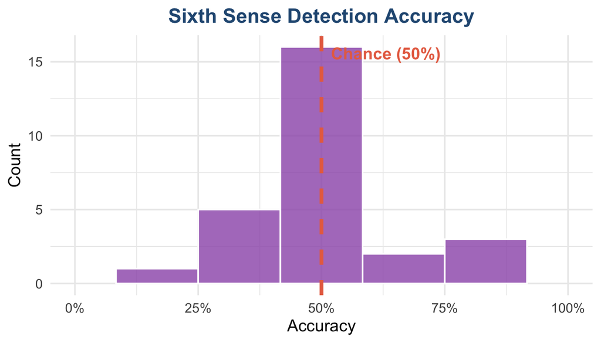

### Group Discussion Questions

**Q6.1** If someone got 5 out of 6 correct, does that **prove** they have a sixth sense?

**Q6.2** Why not?

**Q6.3** What does 50% accuracy suggest?

**Q6.4** What is the **null hypothesis** for this study?

**TipWhy Statistics Matter**

**Statistics help us ask**: Is this result more extreme than we’d expect from chance alone?

## Summary

**ImportantKey Concepts from Today**

**Design Types** (See glossary)

| Type | Same people? | IV? | Test to use | Example |
| --- | --- | --- | --- | --- |
| Between-subjects | No | Yes | Independent t-test | Memory (Lab A vs B) |
| Within-subjects | Yes | Yes | Paired t-test | Throwing (Dom vs Non-dom) |
| Correlational | N/A | No | Correlation | Sleep & Memory |

**Variables**

- **IV (Independent Variable)**: What the researcher manipulates or controls
- **DV (Dependent Variable)**: What the researcher measures

**Hypotheses**

- **Experimental (H1)**: Predicts an effect or difference
- **Null (H0)**: Predicts no effect (any difference is due to chance)
- **One-tailed**: Specifies the direction (“A will be greater than B”)
- **Two-tailed**: Just predicts a difference (“A and B will differ”)

## Next Steps

1. Complete the **Week 12 Self-Assessment Quiz** to test your understanding - these are designed to be identical to assessments
2. Review the **Lecture Reading** for more detail on these concepts
3. Start thinking about your **Research Plan** (due Week 16) - you now have all the vocabulary you need!

**NoteCheck Your Progress**

How many questions did you get correct? Use this as a guide:

- **75-100%**: Great understanding - ready for the self-assessment
- **50-75%**: Good start - review the concepts you missed
- **Below 50%**: Spend time with the lecture reading before the quiz

**Remember**: This is formative - mistakes are learning opportunities!